# Lab 2 Análisis de componentes Pricipales (ACP)

2025-05-18

## Integrantes

### Grupo 6

- Edwin Sanchez
- Stephanie Tamayo
- Andres Felipe Torres
- Fredy Urrea
- Sergio Velasquez
- Manuel Espitia

## Introduccion

### Carga de los datos

Organización de los datos y renombrar variables

```r
CIUDADES<-readxl::read_excel("ciudades original-filtrado-con etiquetas (1).xlsx",
                               sheet = 1)
RHINT<-CIUDADES[,c("CIUDADES","RH_1","RH_2","RH_5","RH_6","RH_7",
                     "RH_8","RH_9","RH_10","RH_11","RH_12","RH_13",
                     "RH_14","RH_15","RH_16","INT_66","INT_67",
                     "INT_68","INT_69","INT_70")]
colnames(RHINT)[2:20] <- c("PC", "TCP","AA","CBPS","CBES","RAP","CC",
                           "CPT","CS","MI","DCFS","VI","H","S","BCPIB",
                           "CI","TOE","DP","DM")
```

## Punto 1

Utilizar la función PCA del paquete FactoMiner para realizar un ACP con todas las variables que le correspondieron al grupo

### Estandarización de datos

```r
RHINTce <- scale(RHINT[,2:20], scale = TRUE, center = TRUE)
colnames(RHINTce) <- colnames(RHINT)[2:20]
rownames(RHINTce) <- RHINT$CIUDADES
```

Realizamos el análisis de componentes principales (PCA) sobre nuestros datos, utilizando todas las variables asignadas al grupo 6 (RH+INT). A partir de este análisis, visualizamos los datos en el círculo unitario, destacando las dos componentes principales que capturan la mayor varianza.

#### Ejecucion del análisis

```r
PCAtodas<-PCA(RHINT[,2:20],scale.unit = T, ncp=7, graph = F)
```

#### Selección de Componentes Principales:

Varianza explicada:

- Componente 1: 23.0% (autovalor: 4.36)
- Componente 2: 19.4% (autovalor: 3.69)
- Componente 3: 12.4% (autovalor: 2.36)

Total acumulado (3 primeros): 54.8%

### Tabla de varianza explicada

Tabla 1. Porcentaje de varianza explicada por los componentes principales

|  | Autovalor | Varianza (%) | Varianza Acumulada (%) |
| --- | --- | --- | --- |
| comp 1 | 4.36 | 22.96 | 22.96 |
| comp 2 | 3.69 | 19.40 | 42.36 |
| comp 3 | 2.36 | 12.43 | 54.78 |
| comp 4 | 2.02 | 10.65 | 65.43 |
| comp 5 | 1.48 | 7.77 | 73.21 |
| comp 6 | 1.27 | 6.69 | 79.90 |
| comp 7 | 1.17 | 6.18 | 86.08 |

### Tabla de correlaciones variables componentes

Tabla 2. Correlaciones entre variables y componentes principales

|  | C1 | C2 | C3 | C4 | C5 | C6 | C7 |
| --- | --- | --- | --- | --- | --- | --- | --- |
| PC | 0.67 | 0.12 | 0.45 | -0.17 | 0.39 | -0.23 | 0.15 |
| TCP | -0.62 | 0.42 | 0.42 | -0.29 | 0.25 | 0.11 | 0.07 |
| AA | -0.6 | 0.62 | 0.26 | -0.32 | -0.12 | 0.04 | 0.14 |
| CBPS | 0.01 | 0.3 | 0.31 | 0.69 | -0.49 | -0.03 | 0 |
| CBES | 0.73 | -0.07 | 0.5 | -0.03 | 0.16 | 0 | 0.26 |
| RAP | -0.45 | 0.57 | 0.46 | 0.19 | -0.11 | -0.25 | 0.09 |
| CC | 0.57 | -0.46 | 0.35 | -0.01 | 0.02 | 0.19 | 0.25 |
| CPT | 0.11 | -0.02 | -0.52 | 0.08 | -0.15 | 0.31 | 0.72 |
| CS | 0.15 | -0.1 | 0.39 | -0.47 | -0.29 | 0.23 | -0.49 |
| MI | -0.32 | 0.59 | 0.16 | -0.25 | 0.27 | 0.54 | 0.12 |
| DCFS | -0.38 | -0.18 | 0.3 | 0.59 | 0.52 | 0.1 | -0.06 |
| VI | -0.28 | -0.34 | 0.24 | 0.65 | 0.31 | 0.03 | -0.09 |
| H | 0.2 | 0.06 | -0.08 | 0.3 | -0.03 | 0.79 | -0.24 |
| S | -0.19 | -0.45 | -0.44 | -0.26 | 0.5 | -0.08 | -0.12 |
| BCPIB | 0.03 | -0.76 | 0.39 | -0.17 | -0.14 | 0.12 | -0.06 |
| CI | 0.32 | 0.8 | -0.34 | 0.13 | 0.25 | -0.05 | -0.07 |
| TOE | 0.67 | 0.46 | -0.1 | -0.01 | 0.29 | 0.06 | -0.23 |
| DP | 0.62 | 0.54 | -0.26 | 0.17 | -0.11 | -0.08 | -0.27 |
| DM | 0.85 | 0.23 | 0.31 | -0.01 | -0.02 | 0.03 | 0.1 |

Note:  
C1–C6: Componentes principales. Las correlaciones con |r| > 0.5 están en negrita.  
<sup>1</sup> Verde: correlación positiva fuerte  
<sup>2</sup> Rojo: correlación negativa fuerte

##### Hallazgo crítico:

- El desarrollo económico (X) no garantiza mejoras en indicadores sociales (Y), requiriendo políticas diferenciadas.

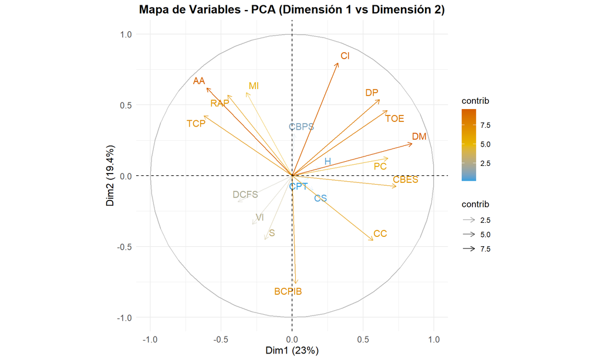

Gráfico de variables (Dim.1 vs Dim.2) - Análisis PCA

##### Hallazgos clave:

- Las variables educativas (ej. Cobertura educación superior) muestran influencia compartida
- Contraste fundamental: Desarrollo económico (Dim.1) ≠ Mejora en seguridad/salud (Dim.3)
- Implica necesidad de políticas diferenciadas para cada dimensión

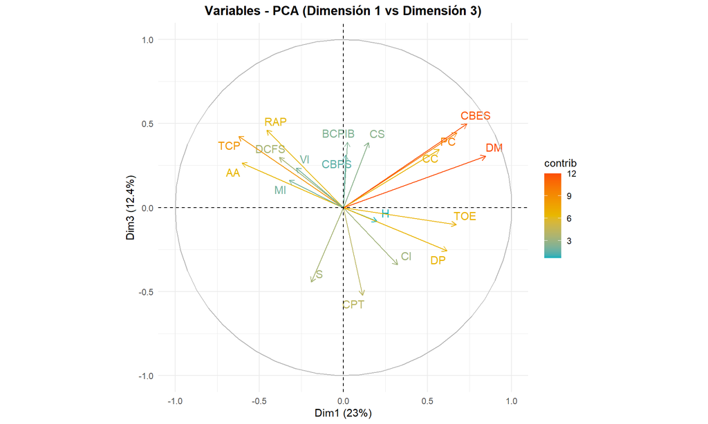

##### Dimensión 2 (Educación/Comercio):

- Variables clave:
  - Cobertura educativa básica
  - Calidad escolar
  - Diversificación productiva
  - Orientación exportadora
  - Interpretación: Eje de capital humano e integración económica

##### Hallazgo clave:

- Las dimensiones revelan que avances educativos/económicos no garantizan mejoras en seguridad/salud, exigiendo intervenciones específicas para cada ámbito.

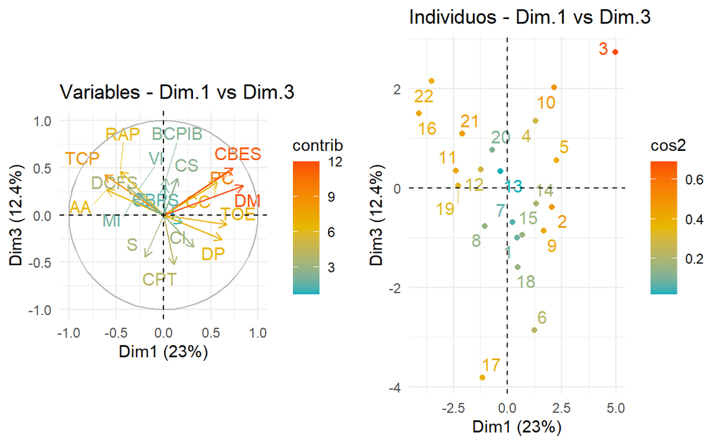

##### Dimensión 2 (Educación-Comercio):

- Separa claramente:
  - Variables educativas (Capacitación laboral)
  - Variables comerciales (Dinámica exportadora)
- Muestra correlación entre:
  - Anafabetismo y Cobertura educativa superior

##### Conclusión:

- Dim.2 complementa el análisis económico (Dim.1) con aspectos de capital humano
- Dim.3 revela desafíos sociales que requieren abordaje específico

#### Las dimensiones muestran que:

- Avances educativos ≠ Mejoras en seguridad
- Desarrollo económico ≠ Solución automática a problemáticas sociales

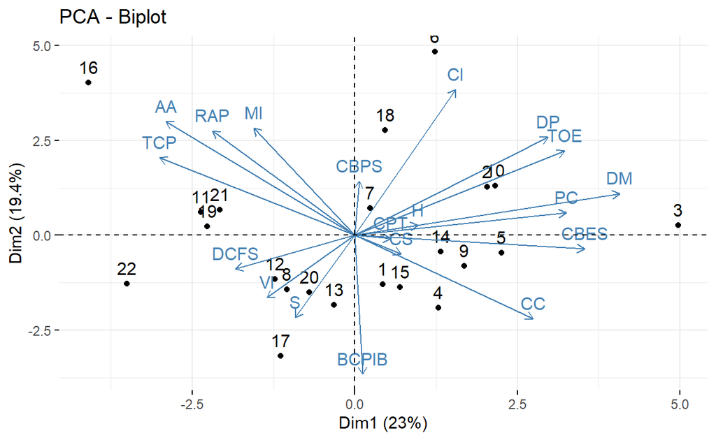

```r
fviz_pca_biplot(PCAtodas)
```

##### Varianza explicada:

- Dim.1: 23% (desarrollo económico)
- Dim.2: 19.4% (capital humano)
- Total: 42.4% de variabilidad

##### Hallazgos clave:

- Perfiles urbanos diferenciados
- Bogotá, Medellín, Cali:
  - Alto desempeño en:
    - Población (PC)
    - Educación superior (CBES)
    - Apertura comercial (DP, TOE)
- Riohacha, Sincelejo:
  - Desafíos en:
    - Analfabetismo (AA)
    - Mortalidad infantil (MI)
    - Crecimiento poblacional (TCP)

##### Posiciones intermedias

- Cartago: Destaca en internacionalización (CI)
- Neiva/Tunja: Perfiles socioeconómicos equilibrados
- Agrupamientos reveladores
  - Ciudades principales (3, 5, 10) comparten patrones de desarrollo
  - Ciudades periféricas (15, 17, 21) muestran trayectorias divergentes

##### Conclusión:

- El biplot evidencia:
  - Desigualdades regionales marcadas
  - Relaciones clave entre desarrollo económico y social
  - Oportunidades para políticas públicas diferenciadas

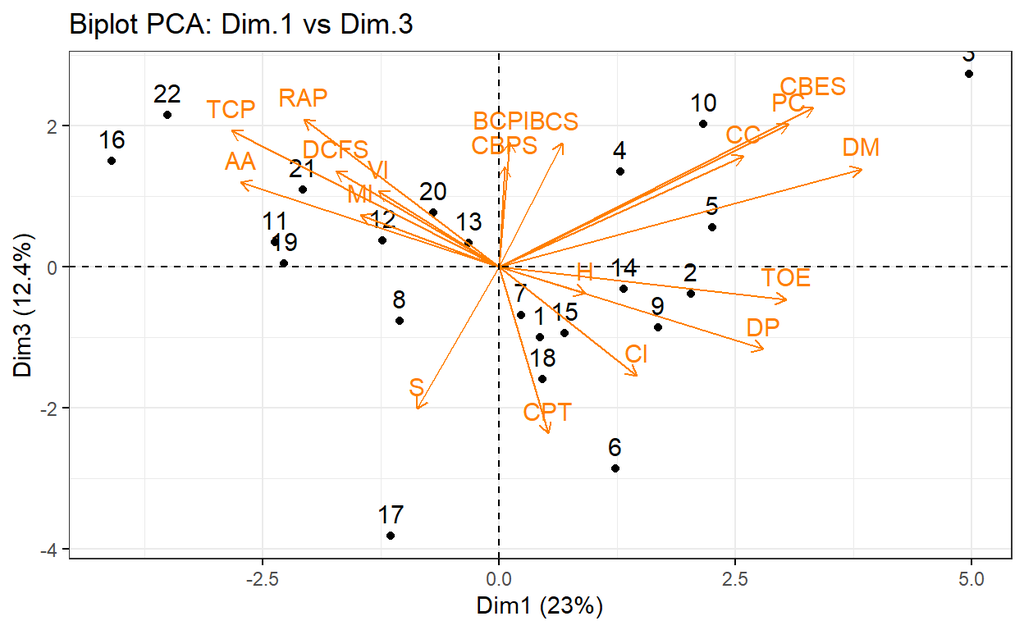

##### Varianza explicada:

- Dim.1: 23% (desarrollo urbano-educativo)
- Dim.3: 12.4% (seguridad y empleo)
- Total: 35.4%

##### Patrones clave:

- Eje de desarrollo (Derecha - Dim.1)
- Diversificación de mercados (DM)
- Población (PC)
- Educación superior (CBES)

##### Conclusiones:

- Confirma el liderazgo de las principales ciudades en desarrollo
- Revela problemas estructurales en educación y seguridad
- Identifica patrones únicos en ciudades intermedias

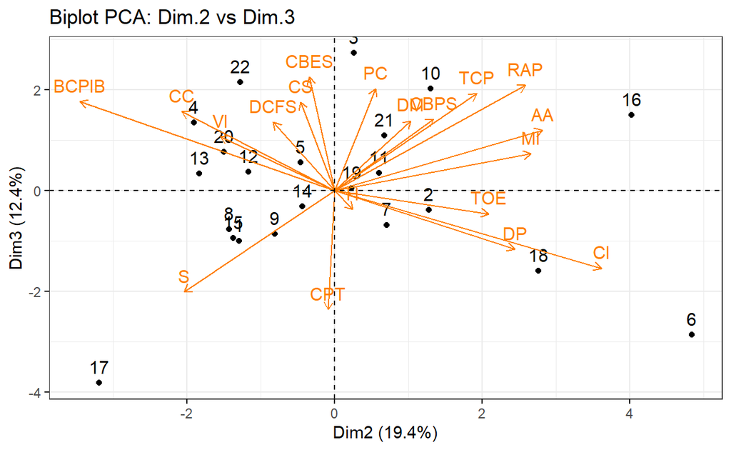

##### Cuadrante superior derecho

- Variables críticas:
  - Analfabetismo (AA)
  - Mortalidad infantil (MI)
- Ciudades asociadas: Riohacha (16), Bogotá (3)
- Interpretación: Nucleo de desafíos sociales persistentes

##### Cuadrante inferior derecho

- Variables económicas:
  - Apertura comercial (TOE, DP)
  - Ciudad destacada: Cartago (6)
- Interpretación: Polos de desarrollo económico

##### Lado izquierdo

- Variables mixtas:
  - Calidad educativa (CC)
  - Violencia intrafamiliar (VI)
- Ciudades: Tunja (20), Pasto (13)
- Interpretación: Perfiles socioeducativos contrastantes

##### Hallazgos clave:

- Bogotá muestra doble condición: desarrollo con rezagos sociales
- Cartago emerge como caso de éxito en apertura económica
- San Andrés (17) y Pereira (14) presentan patrones únicos en seguridad y empleo

## Punto 2

Utilizar la función PCA del paquete FactoMiner para realizar un ACP con todas las varibales especificas del grupo utilizando cOmo ilustrativas las variables de Recursos Humanos.

### Preparación de datos

Seleccionamos las variables activas (internacionalización) y las variables ilustrativas (recursos humanos).

```r
base_acp <- RHINT[, c("BCPIB", "CI", "TOE", "DP", "DM",
                      "PC", "TCP", "AA", "CBPS", "CBES", "RAP", "CC",
                      "CPT", "CS", "MI", "DCFS", "VI", "H", "S")]
```

### Ejecución Análisis de Componentes Principales (ACP)

```r
res.pca <- PCA(base_acp, scale.unit = TRUE, quanti.sup = 6:19, graph = FALSE)
```

### Resultados

#### a) Valores propios

Tabla 3. Valores propios y porcentaje de varianza explicada

|  | Autovalor | Varianza (%) | Varianza Acumulada (%) |
| --- | --- | --- | --- |
| comp 1 | 3.110 | 62.199 | 62.199 |
| comp 2 | 1.162 | 23.238 | 85.437 |
| comp 3 | 0.476 | 9.520 | 94.957 |
| comp 4 | 0.252 | 5.043 | 100.000 |
| comp 5 | 0.000 | 0.000 | 100.000 |

Note:  
Nota: La tabla muestra la importancia relativa de cada componente principal.

##### Dimensión 1 - Apertura Internacional (62.2%)

- Eje de competitividad global
- Alta participación en redes globales (Coef. Internacionalización)
- Economía orientada a exportaciones
- Diversificación productiva (resistencia a crisis)
- Superávit comercial pero bajo dinamismo exportador
- Posible dependencia de pocos sectores

##### Dimensión 2 - Equilibrio Social-Educativo (23.2%)

- Contraste entre desarrollo humano y crecimiento económico
- Superávit comercial + diversificación de mercados
- Estabilidad macroeconómica con proyección internacional
- Ciudades con alto volumen exportador pero:
- Déficits en salud/educación
- Estructura demográfica vulnerable
- Riesgo de sostenibilidad a largo plazo

#### b) Correlaciones de variables activas

Tabla 4. Correlación de variables activas con los factores

|  | Dim.1 | Dim.2 | Dim.3 | Dim.4 | Dim.5 |
| --- | --- | --- | --- | --- | --- |
| BCPIB | -0.699 | 0.672 | 0.218 | 0.113 | 0 |
| CI | 0.924 | -0.352 | 0.104 | -0.103 | 0 |
| TOE | 0.802 | 0.285 | 0.523 | -0.037 | 0 |
| DP | 0.876 | 0.178 | -0.192 | 0.404 | 0 |
| DM | 0.596 | 0.688 | -0.327 | -0.253 | 0 |

Note:  
Nota: Se presentan las correlaciones de las variables originales con los componentes principales. Los valores mayores a |0.5| están resaltados en rojo.

##### Polo Positivo (Ciudades Globalizadas):

- Mayor población y mejor cobertura educativa (primaria a superior)
- Dinamismo económico con oportunidades educativas
- Contraste: Presentan mayores tasas de mortalidad infantil y homicidios (complejidad urbana)

##### Hallazgo Clave:

Las ciudades con mayor apertura global muestran: - Mejor educación y seguridad ciudadana - Pero enfrentan desafíos en salud pública y violencia - Las menos globalizadas tienen crecimiento poblacional sin desarrollo educativo equivalente

#### c) Correlaciones de variables ilustrativas

Tabla 5. Correlación de variables ilustrativas con los factores

|  | Dim.1 | Dim.2 | Dim.3 | Dim.4 | Dim.5 |
| --- | --- | --- | --- | --- | --- |
| PC | 0.397 | 0.583 | 0.062 | -0.436 | 0 |
| TCP | -0.154 | -0.387 | -0.04 | -0.305 | 0 |
| AA | -0.057 | -0.435 | -0.067 | -0.231 | 0 |
| CBPS | 0.163 | -0.026 | -0.277 | 0.112 | 0 |
| CBES | 0.246 | 0.706 | -0.038 | -0.462 | 0 |
| RAP | 0.029 | -0.242 | -0.2 | -0.066 | 0 |
| CC | -0.065 | 0.577 | -0.155 | -0.334 | 0 |
| CPT | 0.076 | -0.128 | -0.164 | -0.04 | 0 |
| CS | -0.079 | 0.34 | -0.066 | 0.086 | 0 |
| MI | 0.168 | -0.319 | 0.163 | -0.313 | 0 |
| DCFS | -0.27 | -0.165 | 0.103 | -0.038 | 0 |
| VI | -0.308 | -0.125 | -0.017 | -0.108 | 0 |
| H | 0.169 | 0.219 | 0.094 | 0.094 | 0 |
| S | -0.273 | -0.162 | 0.137 | 0.127 | 0 |

Note:  
Nota: Se presentan las correlaciones entre variables ilustrativas (cuantitativas suplementarias) y los componentes principales. Los valores mayores a |0.5| están resaltados en rojo.

##### Dimensión 1 (62,2 % de la varianza)

- Relaciona apertura internacional con mejores condiciones sociales.
- Positivas: ciudades grandes con alta cobertura educativa (CBPS, CBES), pero también con mayores tasas de mortalidad infantil y homicidios.
- Negativas: menor violencia intrafamiliar, secuestros y delitos sexuales; menor analfabetismo y crecimiento poblacional en ciudades más internacionalizadas.

##### Dimensión 2 (23,2 % de la varianza)

- Distingue un polo educativo frente a contextos con presión demográfica.
- Positivas: alta cobertura en educación superior (CBES), calidad educativa (CC), mayor población, mejor cobertura en salud.
- Negativas: mayor analfabetismo, crecimiento poblacional y mortalidad infantil en contextos con menor desarrollo educativo.

### Visualizaciones

#### a) Mapa de variables

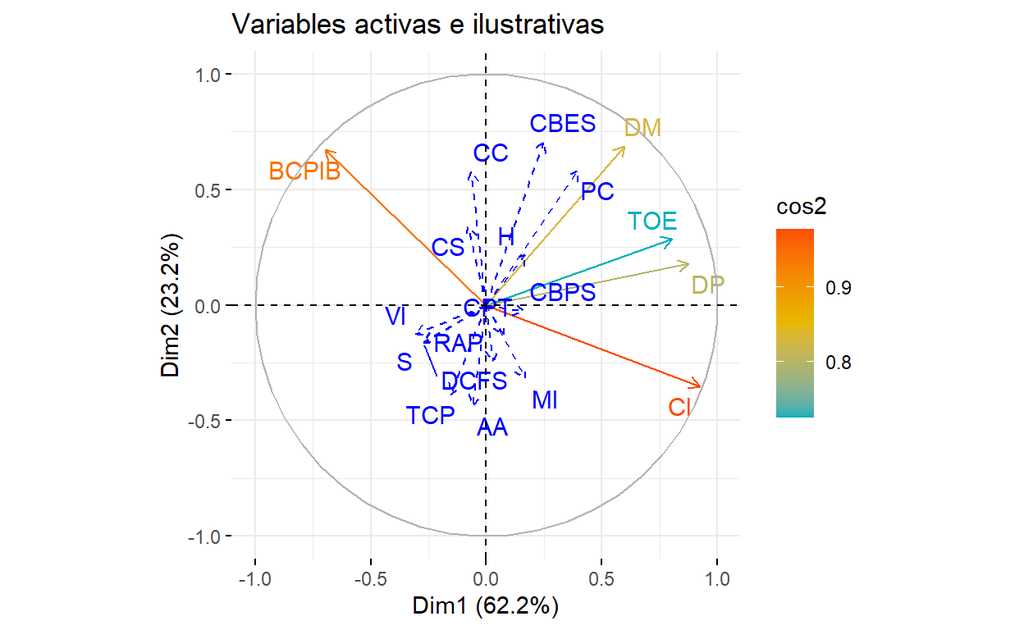

#### b) Biplot

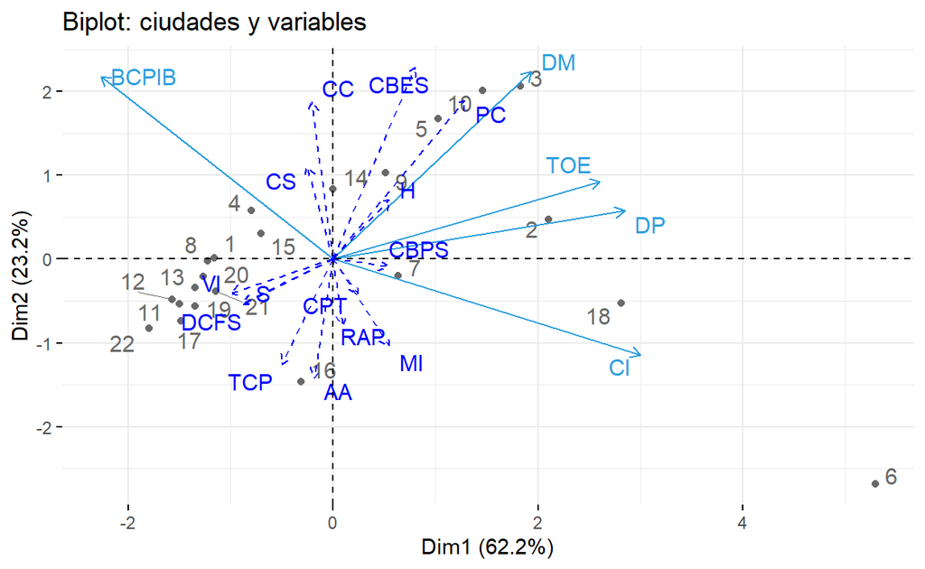

```r
fviz_pca_biplot(res.pca, repel = TRUE,
                col.var = "#2E9FDF", col.ind = "#696969",
                title = "Biplot: ciudades y variables")
```

##### Distribución de ciudades en el plano factorial

Las ciudades se agrupan según dos ejes: apertura internacional y desarrollo social y educativo.

- Cuadrante superior derecho: Ciudades 3, 5 y 10, con alto dinamismo exportador y buena cobertura en educación y salud.
- Cuadrante inferior derecho: Ciudad 6, muy internacionalizada pero con problemas sociales como analfabetismo y crecimiento acelerado.
- Cuadrante superior izquierdo: Ciudades 4 y 8, con superávit comercial y cobertura educativa básica, pero sin fuerte orientación exportadora.
- Cuadrante inferior izquierdo: Ciudades 11, 12 y 17, asociadas a violencia y bajo nivel de internacionalización.

## Punto 3.

Utilizar la funcion PCA del paquete FactoMiner para realizar un ACP de las variables de recursos humanos (RH) utilizando como ilustrativas las que le correspondieron al grupo

### Carga de archivos y ejecucion del ACP

```r
# Estandrizacion y asiganacion de nombres de la filas

RHINTce <- scale(RHINT[,2:20], scale = TRUE, center = TRUE)
colnames(RHINTce) <- colnames(RHINT)[2:20]
rownames(RHINTce) <- RHINT$CIUDADES

require(FactoMineR)
#ACP sin grafica
pcaRHINTce <- PCA(RHINTce, quanti.sup = c(15:19), graph = F, ncp = 6)
#pcaRHINTce
```

### Valores propios y varianza explicada

Tabla 6. Valores propios, porcentaje de varianza y varianza acumulada

|  | Valor propio | % Varianza | % Acumulado |
| --- | --- | --- | --- |
| comp 1 | 3.5715 | 25.5104 | 25.5104 |
| comp 2 | 2.2390 | 15.9932 | 41.5036 |
| comp 3 | 2.0716 | 14.7971 | 56.3007 |
| comp 4 | 1.6027 | 11.4479 | 67.7486 |
| comp 5 | 1.2583 | 8.9880 | 76.7366 |
| comp 6 | 1.1918 | 8.5128 | 85.2494 |
| comp 7 | 0.7712 | 5.5087 | 90.7581 |
| comp 8 | 0.4614 | 3.2959 | 94.0539 |
| comp 9 | 0.3276 | 2.3401 | 96.3941 |
| comp 10 | 0.2153 | 1.5376 | 97.9316 |
| comp 11 | 0.1288 | 0.9199 | 98.8515 |
| comp 12 | 0.0942 | 0.6726 | 99.5241 |
| comp 13 | 0.0538 | 0.3845 | 99.9086 |
| comp 14 | 0.0128 | 0.0914 | 100.0000 |

Note:  
Nota: Se presentan los valores propios y porcentajes de varianza explicada.

### Correlaciones variable factor

Tabla 7. Correlaciones entre variables y las primeras 6 dimensiones

|  | Dim.1 | Dim.2 | Dim.3 | Dim.4 | Dim.5 | Dim.6 |
| --- | --- | --- | --- | --- | --- | --- |
| PC | -0.3569 | 0.7088 | -0.037 | 0.2907 | 0.0014 | 0.4134 |
| TCP | 0.8193 | 0.1945 | -0.1064 | 0.3789 | 0.1926 | 0.0511 |
| AA | 0.9042 | 0.2083 | -0.2736 | -0.0455 | 0.0122 | 0.0645 |
| CBPS | 0.2085 | 0.3028 | 0.63 | -0.5551 | -0.1747 | -0.1542 |
| CBES | -0.516 | 0.7179 | 0.1057 | 0.0908 | 0.1345 | 0.2576 |
| RAP | 0.7936 | 0.3049 | 0.2618 | -0.0864 | -0.2436 | 0.1866 |
| CC | -0.6709 | 0.4063 | 0.1403 | 0.1353 | 0.2379 | -0.039 |
| CPT | -0.2128 | -0.3014 | -0.1846 | -0.5536 | 0.3631 | 0.4263 |
| CS | -0.0764 | 0.4103 | -0.2834 | 0.2444 | 0.0393 | -0.759 |
| MI | 0.6433 | 0.1904 | -0.2198 | 0.0607 | 0.6197 | 0.065 |
| DCFS | 0.218 | -0.1962 | 0.7679 | 0.4088 | 0.2387 | 0.1102 |
| VI | 0.0181 | -0.2347 | 0.8007 | 0.3024 | 0.0763 | -0.0669 |
| H | -0.101 | -0.0445 | 0.1945 | -0.3387 | 0.6877 | -0.3074 |
| S | -0.2064 | -0.6319 | -0.2376 | 0.5359 | 0.0577 | 0.1202 |

Note:  
Nota: Se presentan las correlaciones entre variables y los componentes principales. Los valores mayores a 0.5 están en verde y los menores a -0.5 en rojo.

##### Análisis de Correlaciones Principales (6 primeras dimensiones):

- D1: Analfabetismo↑ + Educación↓
- D2: Educación↑ vs Secuestros↑
- D3: Violencia género (Delitos 0.77, VIF 0.80)
- D5-D6: Salud y violencia vinculadas

### Variables y objetos graficados en distintas dimensiones

#### Variables y ciudades en las Dimensiones 1 y 2

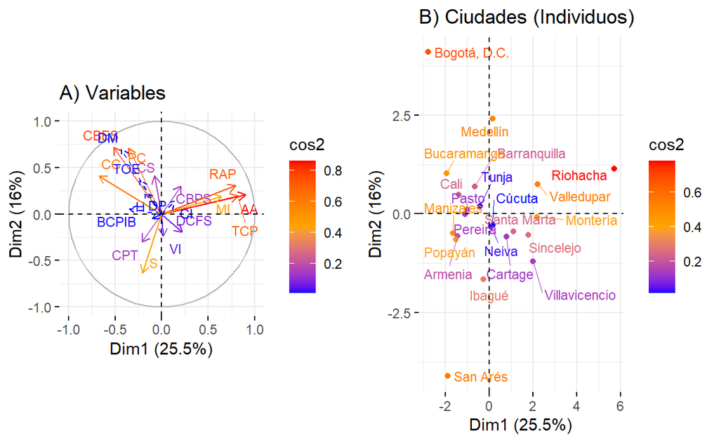

Figura 1. Variables y ciudades en las Dimensiones 1 y 2

##### Análisis de Ciudades y Variables (Dimensiones 1 y 2 - 41.5% varianza total)

- Eje X (25.5%): Destacan Analfabetismos absoluto y relacion alumno profesor → Rioacha
- Eje Y (16%): Destaca CBES Y DM en ciudades como Bogota y Medellin
- Disparidad regional: Bogotá/Medellín vs. Cúcuta/San Andrés en desarrollo y seguridad
- Relación educación-mercados: CBES y DM correlacionan en ciudades desarrolladas
- Variables suplementarias: DM ayudan a contextualizar los ejes principales

#### Variables y ciudades en las Dimensiones 1 y 3

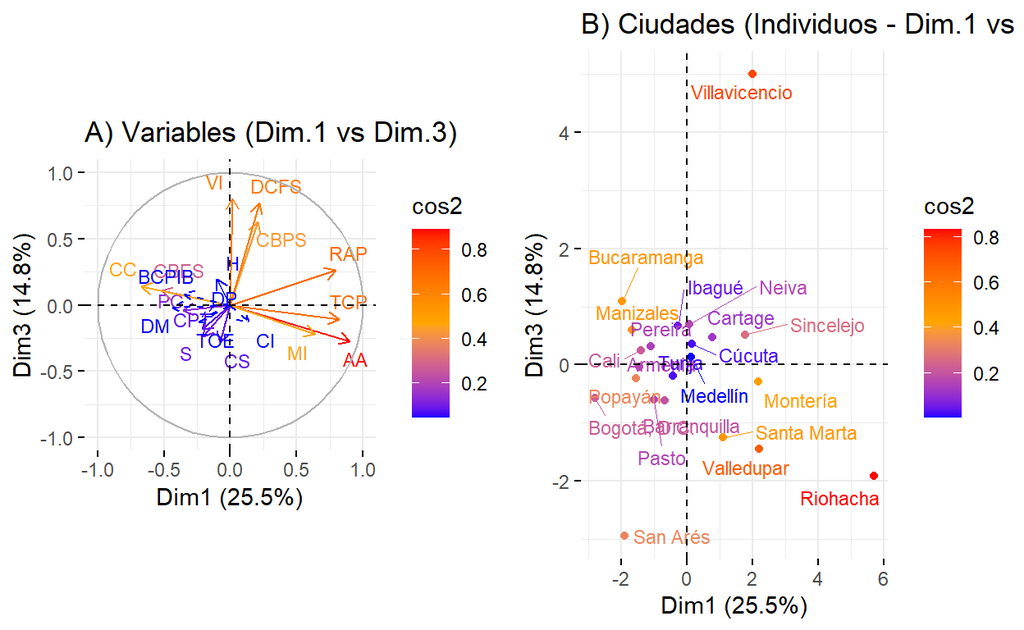

Figura 1.1 Variables y ciudades en las Dimensiones 1 y 3

#### Variables y ciudades en las Dimensiones 3 y 4

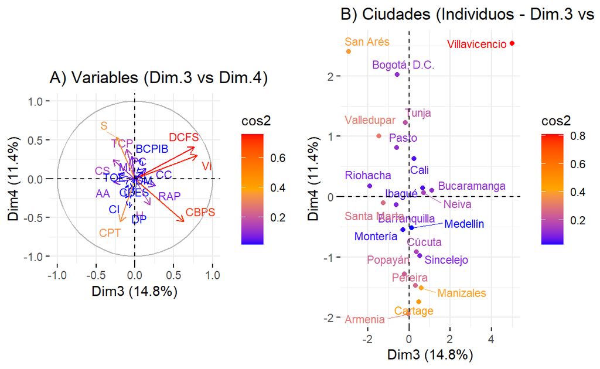

Figura 1. Variables y ciudades en las Dimensiones 3 y 4

##### Análisis Ciudades-Variables (Dim 3 y 4 - 26.2% varianza)

Dos modelos de seguridad:

- Ciudades con violencia doméstica (Villavicencio)
- Formación laboral crítica: Baja capacitación (CPT)

#### Variables y ciudades en las Dimensiones 5 y 6

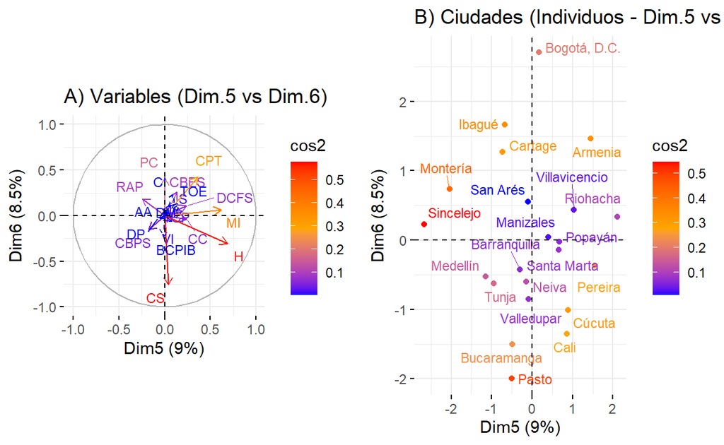

Figura 4. Variables y ciudades en las Dimensiones 5 y 6

##### Análisis Dimensiones 5 y 6 (17.5% varianza total)

- Paradoja capitalina: Bogotá tiene bajos indices de CS

Dos modelos exitosos:

- Ciudades con servicios consolidados Pasto
- Dim5: Salud vs Violencia (H/MI)
- Pasto: Modelo a replicar (CS)

### Biplots

#### Biplot en las Dimensiones 1 y 2

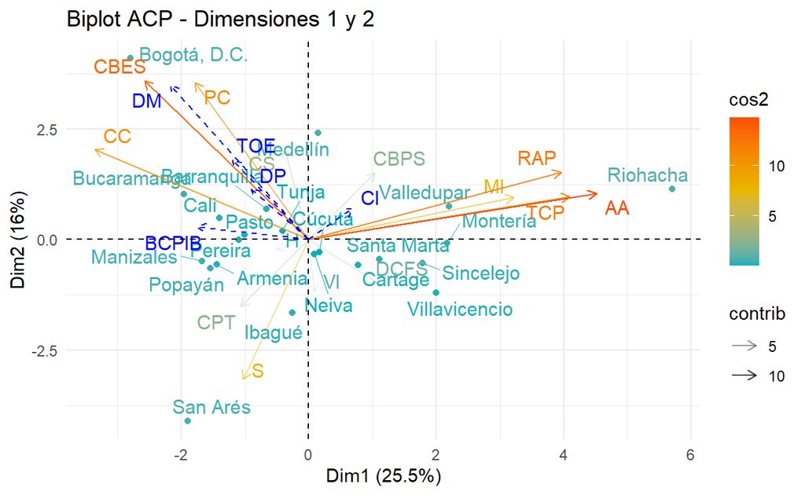

Figura 4. Biplot: Variables y ciudades en las Dimensiones 1 y 2

##### Biplot Dimensiones 1 y 2

El biplot (41.5% varianza total) revela contrastes socioeconómicos entre ciudades:

- Dimensión 1 (25.5%): Seguridad vs. Desarrollo
  - (+) Riohacha: altos indices de Analfabetismos (AA) y (TC)
  - (-) Bogotá: mejor Cobertura en educacion (CBES) y Educación (CC)
- Dimensión 2 (16%): Excelencia educativa
  - (+) Bogotá destacan en Calidad Colegios (CC) y CBES
  - (-) San Andrés/Ibagué: menores indicadores educativos
- Variables suplementarias (internacionalización) correlacionan levemente con ciudades desarrolladas.

#### Biplot en las Dimensiones 1 y 3

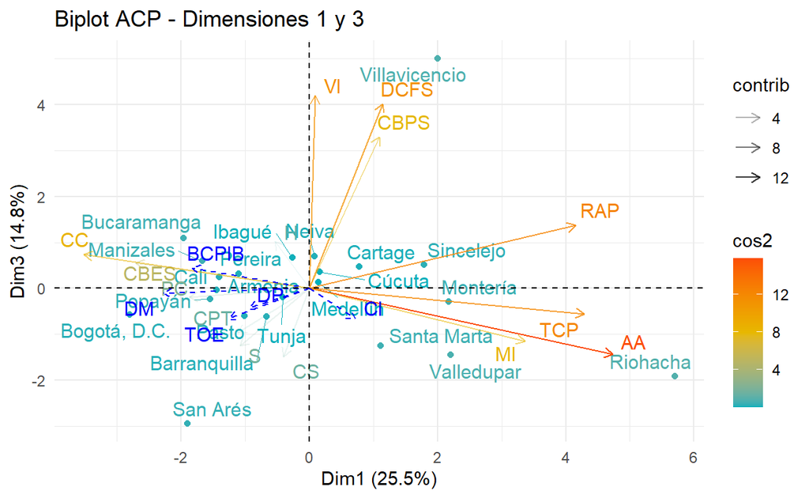

Figura 4.1 biplot Dimensiones 1 y 3

##### Biplot Dimensiones 1 y 3

- Ejes principales (40.3% varianza total):
- Dimensión 1 (25.5%): Contrasta dinamismo demográfico (TCP, AA) con calidad educativa (CC, CBES).
- Dimensión 3 (14.8%): Revela una tensión entre violencia (VI, DCFS) y escolarización básica (CBPS), con ciudades como Villavicencio.
- Hallazgos clave:
  - Variables como Cobertura en Salud (CS) y Secuestros (S) requieren análisis en otras dimensiones para su plena interpretación.
  - Las variables suplementarias (ej: diversificación de mercados) matizan patrones, sugiriendo que factores económicos complementan estas dimensiones.
- Conclusión: Este plano destaca la necesidad de políticas que equilibren crecimiento poblacional, calidad educativa y seguridad, invitando a profundizar en dimensiones adicionales para un diagnóstico integral.

#### Biplot en las Dimensiones 3 y 4

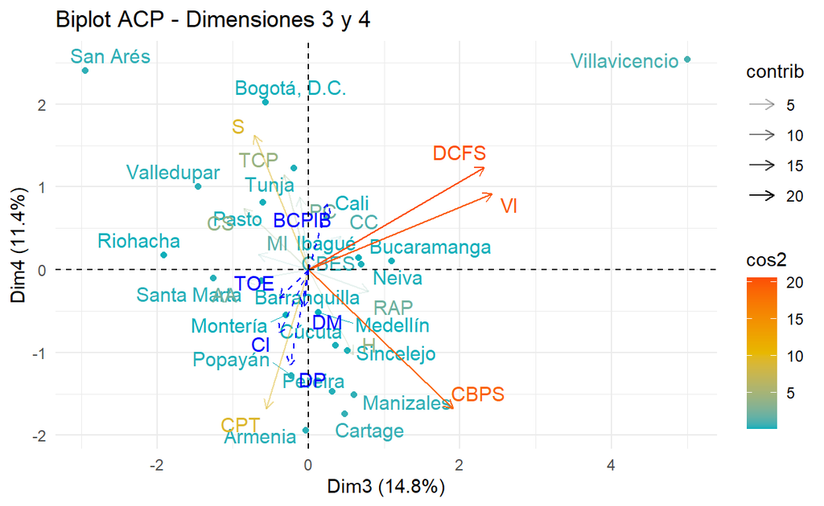

Figura 4. biplot Dimensiones 3 y 4

##### Biplot Dimensiones 3 y 4

- Dimensión 3 (14.8%):
  - Enfoque: Violencia intrafamiliar (VI) y delitos sexuales (DCFS)
  - Ciudades críticas: Vilavicencio (alta incidencia)
  - Necesidad de análisis adicional para casos atípicos

#### Biplot en las Dimensiones 5 y 6

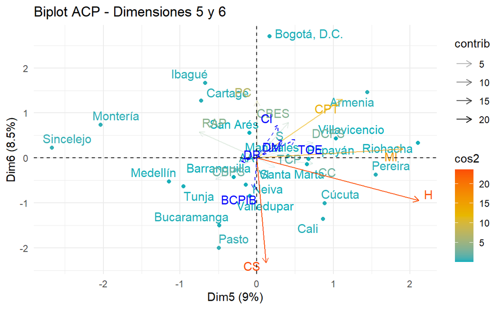

Figura 4. biplot Dimensiones 5 y 6

##### Biplot Dimensiones 5 y 6

- Dimensión 5 (9%):
  - Variable clave: Homicidios (H)
  - Ciudades críticas: Riohacha, Pereira, Cúcuta (alta violencia letal)

### Cosenos cuadrados de los objetos con los factores

#### Tabla Cosenos Cuadrados en la dimensiones 1 y 2

Tabla 8. Resultados del PCA: Coordenadas, Contribución y Calidad de Representación (Cos2)

| Variable | Coord_Dim1 | Coord_Dim2 | Contrib_Dim1 | Contrib_Dim2 | Cos2_Dim1 | Cos2_Dim2 |
| --- | --- | --- | --- | --- | --- | --- |
| PC | -0.3569 | 0.7088 | 3.57 | 22.44 | 0.1274 | 0.5024 |
| TCP | 0.8193 | 0.1945 | 18.80 | 1.69 | 0.6713 | 0.0378 |
| AA | 0.9042 | 0.2083 | 22.89 | 1.94 | 0.8175 | 0.0434 |
| CBPS | 0.2085 | 0.3028 | 1.22 | 4.09 | 0.0435 | 0.0917 |
| CBES | -0.5160 | 0.7179 | 7.46 | 23.02 | 0.2663 | 0.5154 |
| RAP | 0.7936 | 0.3049 | 17.63 | 4.15 | 0.6298 | 0.0930 |
| CC | -0.6709 | 0.4063 | 12.60 | 7.37 | 0.4501 | 0.1651 |
| CPT | -0.2128 | -0.3014 | 1.27 | 4.06 | 0.0453 | 0.0908 |
| CS | -0.0764 | 0.4103 | 0.16 | 7.52 | 0.0058 | 0.1684 |
| MI | 0.6433 | 0.1904 | 11.59 | 1.62 | 0.4138 | 0.0363 |
| DCFS | 0.2180 | -0.1962 | 1.33 | 1.72 | 0.0475 | 0.0385 |
| VI | 0.0181 | -0.2347 | 0.01 | 2.46 | 0.0003 | 0.0551 |
| H | -0.1010 | -0.0445 | 0.29 | 0.09 | 0.0102 | 0.0020 |
| S | -0.2064 | -0.6319 | 1.19 | 17.83 | 0.0426 | 0.3993 |

Note:  
Nota: Se presentan las coordenadas, contribución y calidad de representación de cada variable en las primeras dos dimensiones.

##### Dimensiones 1-2

- Dim1: Anafabetismo (AA) (22.9% contribución)
- Dim2: Educación superior (CBES) (23%) y Población (PC) (22.4%)
- Rol: Estructuran el espacio inicial, diferenciando ciudades según desarrollo educativo y demográfico.

#### Tabla Cosenos Cuadrados en la dimensiones 3 y 4

Tabla 9. Resultados del PCA: Coordenadas, Contribución y Calidad de Representación (Dimensiones 3 y 4)

| Variable | Coord_Dim3 | Coord_Dim4 | Contrib_Dim3 | Contrib_Dim4 | Cos2_Dim3 | Cos2_Dim4 |
| --- | --- | --- | --- | --- | --- | --- |
| PC | -0.04 | 0.29 | 0.07 | 5.27 | 0.00 | 0.08 |
| TCP | -0.11 | 0.38 | 0.55 | 8.96 | 0.01 | 0.14 |
| AA | -0.27 | -0.05 | 3.61 | 0.13 | 0.07 | 0.00 |
| CBPS | 0.63 | -0.56 | 19.16 | 19.23 | 0.40 | 0.31 |
| CBES | 0.11 | 0.09 | 0.54 | 0.51 | 0.01 | 0.01 |
| RAP | 0.26 | -0.09 | 3.31 | 0.47 | 0.07 | 0.01 |
| CC | 0.14 | 0.14 | 0.95 | 1.14 | 0.02 | 0.02 |
| CPT | -0.18 | -0.55 | 1.64 | 19.13 | 0.03 | 0.31 |
| CS | -0.28 | 0.24 | 3.88 | 3.73 | 0.08 | 0.06 |
| MI | -0.22 | 0.06 | 2.33 | 0.23 | 0.05 | 0.00 |
| DCFS | 0.77 | 0.41 | 28.46 | 10.42 | 0.59 | 0.17 |
| VI | 0.80 | 0.30 | 30.95 | 5.70 | 0.64 | 0.09 |
| H | 0.19 | -0.34 | 1.83 | 7.16 | 0.04 | 0.11 |
| S | -0.24 | 0.54 | 2.72 | 17.92 | 0.06 | 0.29 |

Note:  
Nota: Se presentan las coordenadas, contribución y calidad de representación de cada variable en las dimensiones 3 y 4.

#### Tabla Cosenos Cuadrados en la dimensiones 5 y 6

Tabla 10. Resultados del PCA: Coordenadas, Contribución y Calidad de Representación (Dimensiones 5 y 6)

| Variable | Coord_Dim5 | Coord_Dim6 | Contrib_Dim5 | Contrib_Dim6 | Cos2_Dim5 | Cos2_Dim6 |
| --- | --- | --- | --- | --- | --- | --- |
| PC | 0.0014 | 0.4134 | 0.00 | 14.34 | 0.0000 | 0.1709 |
| TCP | 0.1926 | 0.0511 | 2.95 | 0.22 | 0.0371 | 0.0026 |
| AA | 0.0122 | 0.0645 | 0.01 | 0.35 | 0.0001 | 0.0042 |
| CBPS | -0.1747 | -0.1542 | 2.42 | 2.00 | 0.0305 | 0.0238 |
| CBES | 0.1345 | 0.2576 | 1.44 | 5.57 | 0.0181 | 0.0663 |
| RAP | -0.2436 | 0.1866 | 4.72 | 2.92 | 0.0593 | 0.0348 |
| CC | 0.2379 | -0.0390 | 4.50 | 0.13 | 0.0566 | 0.0015 |
| CPT | 0.3631 | 0.4263 | 10.48 | 15.25 | 0.1319 | 0.1817 |
| CS | 0.0393 | -0.7590 | 0.12 | 48.34 | 0.0015 | 0.5761 |
| MI | 0.6197 | 0.0650 | 30.52 | 0.35 | 0.3841 | 0.0042 |
| DCFS | 0.2387 | 0.1102 | 4.53 | 1.02 | 0.0570 | 0.0122 |
| VI | 0.0763 | -0.0669 | 0.46 | 0.38 | 0.0058 | 0.0045 |
| H | 0.6877 | -0.3074 | 37.59 | 7.93 | 0.4730 | 0.0945 |
| S | 0.0577 | 0.1202 | 0.26 | 1.21 | 0.0033 | 0.0144 |

Note:  
Nota: Se presentan las coordenadas, contribución y calidad de representación de cada variable en las dimensiones 5 y 6.

## Punto 4

### Objetivo y enfoque de cada análisis

| Análisis | Variables **activas** | Variables **ilustrativas** | Propósito |
| --- | --- | --- | --- |
| **ACP 1** | Todas (INT + RH) | – | Visión integral |
| **ACP 2** | Internacionalización / economía | Recursos Humanos | Apertura internacional |
| **ACP 3** | Recursos Humanos | Internacionalización | Desigualdad + violencia |

### Comparación completa de varianza

Tabla 2. Comparativa de varianza explicada entre los tres ACP

|  | ACP | Componente | Valor propio | % Varianza | % Acumulado |
| --- | --- | --- | --- | --- | --- |
| **ACP 1** |  |  |  |  |  |
| comp 1…1 | ACP 1 | Comp 1 | 4.36 | 22.96 | 22.96 |
| comp 2…2 | ACP 1 | Comp 2 | 3.69 | 19.40 | 42.36 |
| comp 3…3 | ACP 1 | Comp 3 | 2.36 | 12.43 | 54.78 |
| comp 4…4 | ACP 1 | Comp 4 | 2.02 | 10.65 | 65.43 |
| comp 5…5 | ACP 1 | Comp 5 | 1.48 | 7.77 | 73.21 |
| comp 6…6 | ACP 1 | Comp 6 | 1.27 | 6.69 | 79.90 |
| comp 7…7 | ACP 1 | Comp 7 | 1.17 | 6.18 | 86.08 |
| **ACP 2** |  |  |  |  |  |
| comp 1…8 | ACP 2 | Comp 1 | 3.11 | 62.20 | 62.20 |
| comp 2…9 | ACP 2 | Comp 2 | 1.16 | 23.24 | 85.44 |
| comp 3…10 | ACP 2 | Comp 3 | 0.48 | 9.52 | 94.96 |
| comp 4…11 | ACP 2 | Comp 4 | 0.25 | 5.04 | 100.00 |
| comp 5…12 | ACP 2 | Comp 5 | 0.00 | 0.00 | 100.00 |
| **ACP 3** |  |  |  |  |  |
| comp 1…13 | ACP 3 | Comp 1 | 3.57 | 25.51 | 25.51 |
| comp 2…14 | ACP 3 | Comp 2 | 2.24 | 15.99 | 41.50 |
| comp 3…15 | ACP 3 | Comp 3 | 2.07 | 14.80 | 56.30 |
| comp 4…16 | ACP 3 | Comp 4 | 1.60 | 11.45 | 67.75 |
| comp 5…17 | ACP 3 | Comp 5 | 1.26 | 8.99 | 76.74 |
| comp 6…18 | ACP 3 | Comp 6 | 1.19 | 8.51 | 85.25 |
| comp 7…19 | ACP 3 | Comp 7 | 0.77 | 5.51 | 90.76 |
| comp 8 | ACP 3 | Comp 8 | 0.46 | 3.30 | 94.05 |
| comp 9 | ACP 3 | Comp 9 | 0.33 | 2.34 | 96.39 |
| comp 10 | ACP 3 | Comp 10 | 0.22 | 1.54 | 97.93 |
| comp 11 | ACP 3 | Comp 11 | 0.13 | 0.92 | 98.85 |
| comp 12 | ACP 3 | Comp 12 | 0.09 | 0.67 | 99.52 |
| comp 13 | ACP 3 | Comp 13 | 0.05 | 0.38 | 99.91 |
| comp 14 | ACP 3 | Comp 14 | 0.01 | 0.09 | 100.00 |

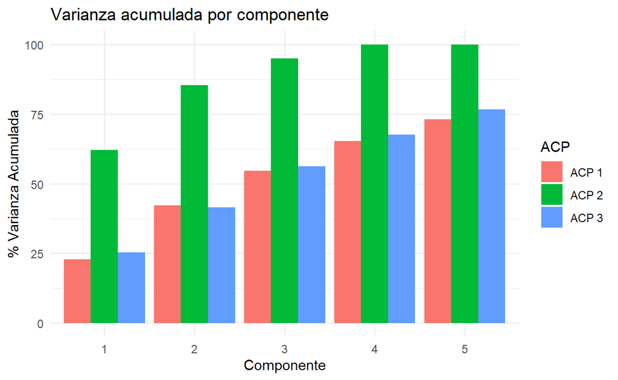

Tabla 3. Nº de componentes necesarios para explicar el 80% de la varianza

|  | ACP | X..Componentes.para.80. |
| --- | --- | --- |
| comp 7 | ACP 1 | 7 |
| comp 2 | ACP 2 | 2 |
| comp 6 | ACP 3 | 6 |

### Significado de los ejes

[output not shown]

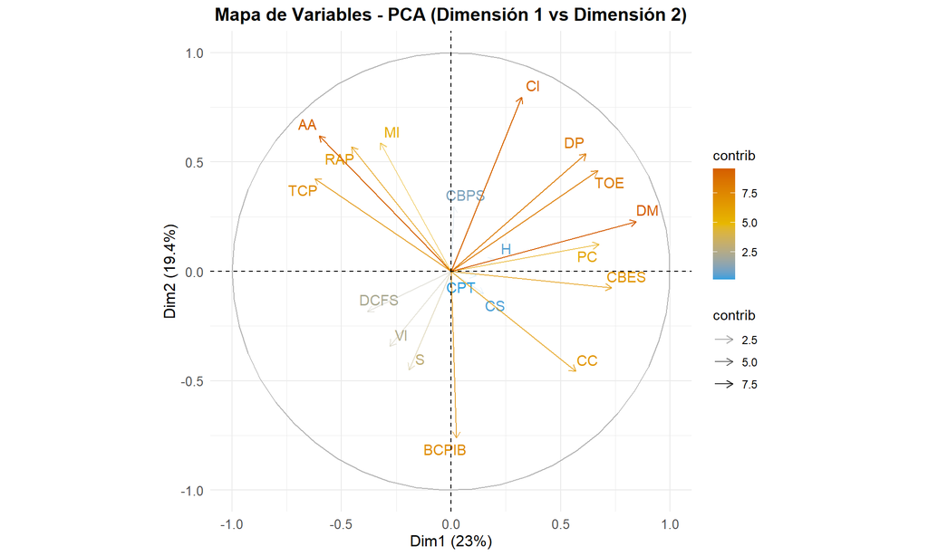

Gráfico de variables (Dim.1 vs Dim.2) - Análisis PCA

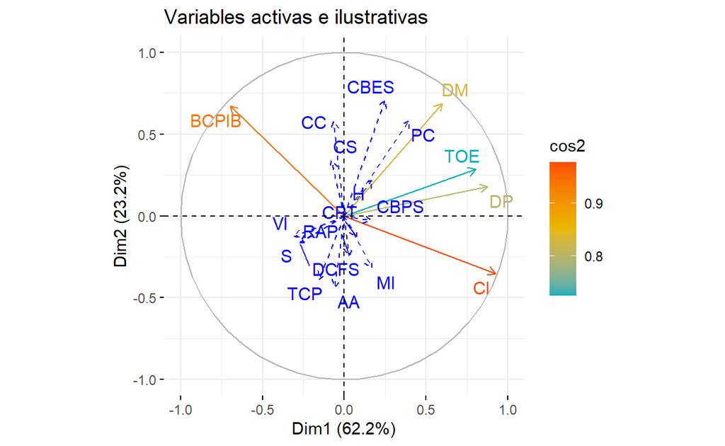

### Agrupamientos de ciudades

| ACP | Ciudades **líderes** | Ciudades **críticas** |
| --- | --- | --- |
| **1** | Bogotá, Medellín, Cali | Riohacha, Sincelejo |
| **2** | Cartago, Manizales | Neiva |
| **3** | Bucaramanga | Villavicencio |

### Ventajas y limitaciones

| ACP | Ventaja | Limitación |
| --- | --- | --- |
| **1** | Visión holística | ≥ 6 componentes para 80 % |
| **2** | 85 % varianza con 2 ejes | Menor detalle social |
| **3** | Enfoque en brechas sociales | Solo 42 % en 2 ejes |

### Síntesis gráfica

La calidad de representación (cos²) es mayor en ACP 2 → visualización más fiable.

### Interpretación final

- ACP 1: panorámica general.
- ACP 2: énfasis en desarrollo económico-educativo.
- ACP 3: revela brechas sociales.

### Conclusiones integradas

- Complementariedad – cada ACP ilumina una faceta distinta (económica, internacional y social).
- Eficiencia – ACP 2 es el mejor resumen 2-D.
- Profundidad social – ACP 3 revela desigualdades invisibles en análisis puramente económicos.
- Política pública – integrar los hallazgos permite estrategias que combinen competitividad, capital humano y seguridad.